# Improving_support_team_workload_experiment

## Task Description

Imagine that you’re working for an airline. Your task is to reduce their support team workload by creating a chatbot that can direct visitors to the correct page (e.g. the flight search). Unknown inputs are still handled with the help of a human.

The product team is asking you to help them build that tool and to estimate the workload reduction. Further, a process should be mapped out to ensure the bot’s accuracy over time. What would your advice be?

Note: Please use any of the free popular Notebook providers (Kaggle, Colab, ...) or upload the final notebook to GitHub and share it with us. Python is strongly preferred (unless there’s a good reason to use something else).

## Problem statement

As a data scientist/machine learning engineer working for an airline, we want to reduce the workload of support team so that we can save time and manpower.

### Current State

Right now, it is a manual process to direct people to the correct page when they have support queries.

### Stakeholder Proposed Solution

Would it be possible to automate this process by building a machine learning model that can help to automatically direct most visitors to the right page?

### Key Assumptions for Stakeholder Proposed Solution

1. That we have or can obtain enough labelled data to support the model identifying intents (assumed true, atis dataset)
2. That a machine learning model can automatically predict what page people want to go to (intent) from the their queries (to be validated)
3. That we do have concrete webpages that maps to each of the identified intents (assumed true) - this could be in a lookup table, so perhaps if the result is atis_flights, we return www.atis.com/flights
4. That we would not have the chatbot ask queries for more details where there is some uncertainty (assumed true, as unknown inputs handled with help of human)

### Alternatives to stakeholder proposed solution that also solve the problem of reduce the workload of support team

1. Improving UI/UX of support pages (i.e. most people looked for X and Y data, is this what you are looking for?)

##### We should always think about alternatives because sometimes, it is possible for alternative solutions to achieve the initial business objective without machine learning, in some cases at a much lower cost and effort. In this case, we assume that the machine learning approach was chosen by the stakeholder

### Additional Stakeholder Requirements

1. To estimate the workload reduction - specifically measure how often human intervention is required?
2. Further, a process should be mapped out to ensure the bot’s accuracy over time.

## Step 1 : Validating Assumptions and Building PoC Model

Overall approach

1. Some EDA, cleaning up
2. classical model, using BoW, tfidf and Random Forests (~93% F1 score)
3. neural pre-trained BERT model to finetune on problem, and see if we can improve results (~98% F1 score)

## Step 2 : Architecting

1. How does model fit into entire framework?
2. Track and visualise metrics and predictions
3. How to ensure the bot’s accuracy over time.

## Step 1 : Validating Assumptions and Building PoC Model

### Modelling - EDA : Always good to get a sense of the dataset

```python
import pandas as pd
```

```python
raw = pd.read_csv("../data/atis_intents.csv",names=["intents","text"])
```

```python
from pandas_profiling import ProfileReport
ProfileReport(raw)
```

[interactive chart not shown]

### From profile report (only shows if you are viewing .html, not on .ipynb)

- Duplicate rows are around - lets drop them
- Text maxes out at 260 words, should be ok for all analysis
- Doesn't seem to be outliers in the text space
- Many distinct intents - might want to look at that a bit

### lets look at the intents a bit deeper

```python
raw["intents"].unique()
```

```
array(['atis_flight', 'atis_flight_time', 'atis_airfare', 'atis_aircraft',
       'atis_ground_service', 'atis_airport', 'atis_airline',
       'atis_distance', 'atis_abbreviation', 'atis_ground_fare',
       'atis_quantity', 'atis_city', 'atis_flight_no', 'atis_capacity',
       'atis_flight#atis_airfare', 'atis_meal', 'atis_restriction',
       'atis_airline#atis_flight_no',
       'atis_ground_service#atis_ground_fare',
       'atis_airfare#atis_flight_time', 'atis_cheapest',
       'atis_aircraft#atis_flight#atis_flight_no'], dtype=object)
```

### Seems like the same text can have multiple intents - we should label it properly

### Lets split into multiple rows first , then regroup them later

```python
raw["intent_splits"] = raw["intents"].apply(lambda x: tuple(x.split("#")))
```

```python
exploded_df = raw.explode("intent_splits")
```

```python
exploded_df["intent_splits"].value_counts()
```

```
atis_flight            3688
atis_airfare            445
atis_ground_service     256
atis_airline            159
atis_abbreviation       147
atis_aircraft            82
atis_flight_time         55
atis_quantity            51
atis_airport             20
atis_distance            20
atis_ground_fare         19
atis_city                19
atis_capacity            16
atis_flight_no           15
atis_meal                 6
atis_restriction          6
atis_cheapest             1
Name: intent_splits, dtype: int64
```

### There is also a very rare intent (==1). Lets drop this as we probably cannot predict it well.

### Lets also remember what % of data they comprise because we will not be able to predict them

```python
percentage_of_data = 100*sum(exploded_df["intent_splits"].value_counts().where(lambda x:x==1).dropna())/sum(exploded_df["intent_splits"].value_counts())
print(f"We drop {round(percentage_of_data,2)}% of data that is of label atis_cheapest")
```

```
We drop 0.02% of data that is of label atis_cheapest
```

### We should remember that some ~0.02% of our data we will never be able to predict

```python
exploded_df["intent_splits"].value_counts().where(lambda x:x==1).dropna().index
```

```
Index(['atis_cheapest'], dtype='object')
```

```python
raw_subset = exploded_df[exploded_df["intent_splits"]!= "atis_cheapest"].copy()
```

```python
raw_subset["intent_splits"].unique()
```

```
array([('atis_flight',), ('atis_flight_time',), ('atis_airfare',),
       ('atis_aircraft',), ('atis_ground_service',), ('atis_airport',),
       ('atis_airline',), ('atis_distance',), ('atis_abbreviation',),
       ('atis_ground_fare',), ('atis_quantity',), ('atis_city',),
       ('atis_flight_no',), ('atis_capacity',), ('atis_meal',),
       ('atis_restriction',)], dtype=object)
```

### Great we removed the class that is very rare, lets now clean our dataset up a bit more

### lets drop duplicates here to clean our dataset

```python
# clean up duplicates here also
raw_subset.drop_duplicates(inplace=True)
```

### And lets regroup our data before splitting them into train and test so that text with multiple labels are combined together and not split into train/test

```python
raw_subset["intent_splits"] = raw_subset["intent_splits"].apply(lambda x:(x,))
```

```python
regrouped_df = pd.DataFrame(raw_subset.groupby("text")["intent_splits"].sum())
```

```python
regrouped_df["intent_splits"].value_counts()
```

```
(atis_flight,)                                  3426
(atis_airfare,)                                  403
(atis_ground_service,)                           235
(atis_airline,)                                  148
(atis_abbreviation,)                             108
(atis_aircraft,)                                  78
(atis_flight_time,)                               52
(atis_quantity,)                                  49
(atis_distance,)                                  20
(atis_airport,)                                   18
(atis_city,)                                      18
(atis_ground_fare,)                               17
(atis_flight, atis_airfare)                       17
(atis_capacity,)                                  16
(atis_flight_no,)                                 12
(atis_meal,)                                       6
(atis_restriction,)                                5
(atis_airline, atis_flight_no)                     2
(atis_aircraft, atis_flight, atis_flight_no)       1
(atis_airfare, atis_flight_time)                   1
(atis_ground_service, atis_ground_fare)            1
Name: intent_splits, dtype: int64
```

```python
from sklearn.model_selection import train_test_split
```

```python
X_train, X_test, y_train, y_test = train_test_split(regrouped_df, regrouped_df.intent_splits, test_size=0.2, random_state=43)
```

```python
y_train.value_counts()
```

```
(atis_flight,)                                  2736
(atis_airfare,)                                  314
(atis_ground_service,)                           194
(atis_airline,)                                  125
(atis_abbreviation,)                              81
(atis_aircraft,)                                  64
(atis_flight_time,)                               45
(atis_quantity,)                                  40
(atis_distance,)                                  16
(atis_airport,)                                   15
(atis_flight, atis_airfare)                       15
(atis_city,)                                      14
(atis_ground_fare,)                               13
(atis_flight_no,)                                 12
(atis_capacity,)                                  10
(atis_meal,)                                       4
(atis_restriction,)                                4
(atis_airline, atis_flight_no)                     2
(atis_aircraft, atis_flight, atis_flight_no)       1
(atis_airfare, atis_flight_time)                   1
Name: intent_splits, dtype: int64
```

```python
y_test.value_counts()
```

```
(atis_flight,)                             690
(atis_airfare,)                             89
(atis_ground_service,)                      41
(atis_abbreviation,)                        27
(atis_airline,)                             23
(atis_aircraft,)                            14
(atis_quantity,)                             9
(atis_flight_time,)                          7
(atis_capacity,)                             6
(atis_distance,)                             4
(atis_city,)                                 4
(atis_ground_fare,)                          4
(atis_airport,)                              3
(atis_flight, atis_airfare)                  2
(atis_meal,)                                 2
(atis_ground_service, atis_ground_fare)      1
(atis_restriction,)                          1
Name: intent_splits, dtype: int64
```

### now lets properly convert our labels into a multilabel vector

```python
from sklearn.preprocessing import MultiLabelBinarizer

ylabel_multilabel_binarizer = MultiLabelBinarizer()
ylabel_multilabel_binarizer.fit([i[0] for i in y_train.values.reshape(-1,1)])

# Rebuild y train and y test based on new multilabel samples
y_train = ylabel_multilabel_binarizer.transform([i[0] for i in y_train.values.reshape(-1,1)])
y_test = ylabel_multilabel_binarizer.transform([i[0] for i in y_test.values.reshape(-1,1)])
```

```python
label_names = ylabel_multilabel_binarizer.classes_
ylabel_multilabel_binarizer.classes_
```

```
array(['atis_abbreviation', 'atis_aircraft', 'atis_airfare',
       'atis_airline', 'atis_airport', 'atis_capacity', 'atis_city',
       'atis_distance', 'atis_flight', 'atis_flight_no',
       'atis_flight_time', 'atis_ground_fare', 'atis_ground_service',
       'atis_meal', 'atis_quantity', 'atis_restriction'], dtype=object)
```

### labels are now a vector of possible intents, and a text can have multiple intents

```python
y_test[0]
```

```
array([0, 0, 0, 0, 0, 0, 0, 0, 1, 0, 0, 0, 0, 0, 0, 0])
```

### Great we are now ready to see if we can accurately predict intents

### Approach 1 - simple bag of words, tfidf, then random forest

### Considerations -

1. Not too much tuning required for baseline stats
2. Generally robust
3. Good baseline model
4. Can see importance using permutation or feature importance

```python
from sklearn.pipeline import Pipeline
from sklearn.feature_extraction.text import TfidfTransformer, CountVectorizer
from sklearn.ensemble import RandomForestClassifier
from sklearn.multioutput  import MultiOutputClassifier

text_clf = Pipeline([
     ('vect', CountVectorizer(stop_words="english")),
     ('tfidf', TfidfTransformer()),
     ('clf', MultiOutputClassifier(RandomForestClassifier(max_depth=40), n_jobs=-1)),
 ])
```

### Training metrics

```python
from sklearn.metrics import confusion_matrix, classification_report

text_clf.fit(X_train.index, y_train)
predicted = text_clf.predict(X_train.index)
print((classification_report(y_train,predicted,target_names=label_names)))
```

```
                     precision    recall  f1-score   support

  atis_abbreviation       1.00      0.95      0.97        81
      atis_aircraft       1.00      1.00      1.00        65
       atis_airfare       0.99      0.99      0.99       330
       atis_airline       1.00      0.98      0.99       127
       atis_airport       1.00      0.93      0.97        15
      atis_capacity       1.00      1.00      1.00        10
          atis_city       1.00      1.00      1.00        14
      atis_distance       1.00      1.00      1.00        16
        atis_flight       0.98      1.00      0.99      2752
     atis_flight_no       1.00      1.00      1.00        15
   atis_flight_time       1.00      1.00      1.00        46
   atis_ground_fare       1.00      1.00      1.00        13
atis_ground_service       1.00      1.00      1.00       194
          atis_meal       1.00      1.00      1.00         4
      atis_quantity       1.00      0.97      0.99        40
   atis_restriction       1.00      1.00      1.00         4

          micro avg       0.99      1.00      0.99      3726
          macro avg       1.00      0.99      0.99      3726
       weighted avg       0.99      1.00      0.99      3726
        samples avg       0.99      1.00      0.99      3726
```

### Training metrics look very good - a bit too good to be true? Probably overfitted quite a bit

### Eval/Test metrics

```python
from sklearn.metrics import confusion_matrix, classification_report
predicted = text_clf.predict(X_test.index)
print((classification_report(y_test,predicted,target_names=label_names)))
```

```
                     precision    recall  f1-score   support

  atis_abbreviation       0.94      0.63      0.76        27
      atis_aircraft       0.87      0.93      0.90        14
       atis_airfare       0.90      0.88      0.89        91
       atis_airline       1.00      0.61      0.76        23
       atis_airport       0.50      0.67      0.57         3
      atis_capacity       0.33      0.17      0.22         6
          atis_city       0.50      0.25      0.33         4
      atis_distance       0.00      0.00      0.00         4
        atis_flight       0.95      0.98      0.96       692
     atis_flight_no       0.00      0.00      0.00         0
   atis_flight_time       0.67      0.29      0.40         7
   atis_ground_fare       0.00      0.00      0.00         5
atis_ground_service       0.95      1.00      0.98        42
          atis_meal       0.00      0.00      0.00         2
      atis_quantity       1.00      0.33      0.50         9
   atis_restriction       0.00      0.00      0.00         1

          micro avg       0.94      0.92      0.93       930
          macro avg       0.54      0.42      0.45       930
       weighted avg       0.92      0.92      0.91       930
        samples avg       0.91      0.92      0.91       930
```

### Thoughts : Eval F1 scores look ok, but we are doing badly on the very small sample datapoints. We're doing kinda ok on the higher ones though, and the micro F1 is 0.93 which is not too bad

### There definitely is overfitting for this model because training F1 is 0.99, and eval F1 is 0.93. However, I think we should move on to the neural network approach because leveraging on pre-trained models would likely get us much further

### Before we go on to neural models, lets calculate feature importances to get a rough sense of what the model is predicting on for a single class - atis_flight

[output not shown]

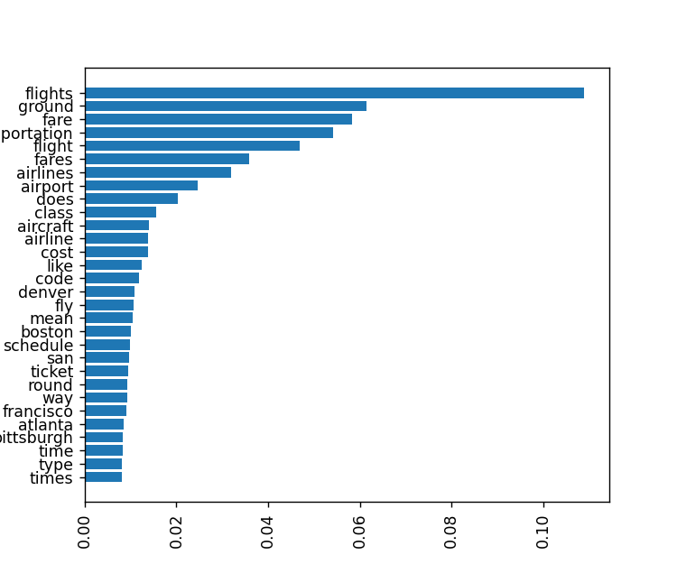

```python
import matplotlib
matplotlib.use('nbAgg')

import matplotlib.pyplot as plt

rf_model = text_clf.named_steps["clf"].estimators_[8]

get_importances = []
for feature, importance in zip(text_clf.named_steps["vect"].get_feature_names(), rf_model.feature_importances_):
    get_importances.append((feature, importance))
get_importances.sort(key=lambda x: x[1],reverse=True)
# find out what the model uses to predict
plt.figure(figsize = (6,5))
plt.barh([i[0] for i in reversed(get_importances[:30])],width=[i[1] for i in reversed(get_importances[:30])])
print(get_importances[:30])
plt.xticks(size=10,rotation=90)
plt.show()
```

### Makes sense - seems like the classical model works pretty well out of the box. Lets try to do better with a pre-trained language model

### This can hopefully capture the underlying semantic meaning better

### Model chosen : distilbert-base-uncased - simple language model, small, great for a start , not fine-tuned for any other problem. What we can do then is finetune it to solve this multilabel classification problem specifically

```python
from transformers import AutoModel, AutoTokenizer, AutoModelForSequenceClassification


# Define the model repo
model_name = "distilbert-base-uncased"
#model_name = "bert-base-cased"

# Download pytorch model
tokenizer = AutoTokenizer.from_pretrained(model_name)
```

### Here we take note to make it a multilabel problem so that we can do multilabel predictions too

```python
model = AutoModelForSequenceClassification.from_pretrained(model_name, num_labels=16, problem_type="multi_label_classification")
```

[output not shown]

```python
X_train.index.values[0]
```

```
' list flights from boston to san francisco that serve only breakfast'
```

```python
len(y_train[0])
```

```
16
```

```python
list(X_train.index.values)[:5]
```

```
[' list flights from boston to san francisco that serve only breakfast',
 ' give me the flights from washington dc to philadelphia for december second',
 " i'd like information on a flight from atlanta to denver a morning flight",
 ' what is the latest departure from boston to pittsburgh on the seventh of july',
 ' what flights are available friday afternoon from atlanta to dallas']
```

```python
train = pd.DataFrame.from_dict({"text":list(X_train.index.values),"labels":list(y_train)})
test = pd.DataFrame.from_dict({"text":list(X_test.index.values),"labels":list(y_test)})
```

```python
import pickle
pickle.dump(train,open("../data/train.pkl","wb"))
pickle.dump(test,open("../data/test.pkl","wb"))
```

### Using wandb to track model training metrics, but can be changed

```python
from datasets import Dataset
import wandb
wandb.login()
from datasets import load_dataset
dataset = load_dataset('pandas', data_files={"train":f"../data/train.pkl",
                                            "eval":f"../data/test.pkl"})
```

```
Failed to detect the name of this notebook, you can set it manually with the WANDB_NOTEBOOK_NAME environment variable to enable code saving.
wandb: Currently logged in as: edwinchan (use `wandb login --relogin` to force relogin)
Using custom data configuration default-aebfb7d064a4ba6f
```

```
Downloading and preparing dataset pandas/default to /home/edwin/.cache/huggingface/datasets/pandas/default-aebfb7d064a4ba6f/0.0.0/6197c1e855b639d75a767140856841a562b7a71d129104973fe1962594877ade...
```

```
Dataset pandas downloaded and prepared to /home/edwin/.cache/huggingface/datasets/pandas/default-aebfb7d064a4ba6f/0.0.0/6197c1e855b639d75a767140856841a562b7a71d129104973fe1962594877ade. Subsequent calls will reuse this data.
```

```python
dataset["train"][0]
```

```
{'text': ' list flights from boston to san francisco that serve only breakfast',
 'labels': [0, 0, 0, 0, 0, 0, 0, 0, 1, 0, 0, 0, 0, 0, 0, 0]}
```

```python
import torch
```

### Model training code :

```python
from transformers import AutoModelForSequenceClassification, TrainingArguments, Trainer
from sklearn.metrics import precision_recall_fscore_support, accuracy_score
batch_size=4

tokenizer = AutoTokenizer.from_pretrained(model_name, use_fast=True)

def preprocess_function(examples):
    return tokenizer(examples["text"], truncation=True,max_length=512)


def tokenize(batch):
    batch['labels'] = [torch.tensor(list(float(j) for j in i),dtype=torch.float64) for i in batch['labels']]
    return batch

dataset = dataset.map(tokenize, batched=True)
encoded_dataset = dataset.map(preprocess_function, batched=True)
encoded_dataset = encoded_dataset.remove_columns("text")

encoded_dataset.set_format("torch")
encoded_dataset = (encoded_dataset
          .map(lambda x : {"float_labels": x["labels"].to(torch.float)}, remove_columns=["labels"])
          .rename_column("float_labels", "labels"))

model = model.to("cuda")

metric_name = "f1"

args = TrainingArguments(
    "airline_intents_model",
    evaluation_strategy = "epoch",
    save_strategy = "epoch",
    learning_rate=2e-5,
    per_device_train_batch_size=batch_size,
    per_device_eval_batch_size=batch_size,
    num_train_epochs=10,
    weight_decay=0.01,
    load_best_model_at_end=True,
    metric_for_best_model=metric_name,
    report_to="wandb"
)


def compute_metrics(pred):
    labels = pred.label_ids
    preds = []
    for prediction in pred.predictions:
        preds.append([1 if i>=1 else 0 for i in prediction])
    precision, recall, f1, _ = precision_recall_fscore_support(labels, preds, average='micro')
    acc = accuracy_score(labels, preds)
    return {
        'accuracy': acc,
        'f1': f1,
        'precision': precision,
        'recall': recall
    }

trainer = Trainer(
model,
args,
train_dataset=encoded_dataset["train"],
eval_dataset=encoded_dataset["eval"],
tokenizer=tokenizer,
compute_metrics=compute_metrics
)

trainer.train()

model.save_pretrained(f"../models/model_airline_intents.pkl")
```

```
***** Running training *****
  Num examples = 3706
  Num Epochs = 10
  Instantaneous batch size per device = 4
  Total train batch size (w. parallel, distributed & accumulation) = 4
  Gradient Accumulation steps = 1
  Total optimization steps = 9270
Automatic Weights & Biases logging enabled, to disable set os.environ["WANDB_DISABLED"] = "true"
wandb: wandb version 0.12.11 is available!  To upgrade, please run:
wandb:  $ pip install wandb --upgrade
```

Syncing run **[airline_intents_model](https://wandb.ai/edwinchan/huggingface/runs/32anzxei)** to [Weights & Biases](https://wandb.ai/edwinchan/huggingface) ([docs](https://docs.wandb.com/integrations/jupyter.html)).

[9270/9270 18:49, Epoch 10/10]

| Epoch | Training Loss | Validation Loss | Accuracy | F1 | Precision | Recall |
| --- | --- | --- | --- | --- | --- | --- |
| 1 | 0.136400 | 0.021614 | 0.897519 | 0.942970 | 0.992866 | 0.897849 |
| 2 | 0.017300 | 0.011947 | 0.956850 | 0.972678 | 0.988889 | 0.956989 |
| 3 | 0.008900 | 0.009108 | 0.964401 | 0.978839 | 0.987952 | 0.969892 |
| 4 | 0.004800 | 0.007130 | 0.971953 | 0.982094 | 0.991238 | 0.973118 |
| 5 | 0.003100 | 0.007252 | 0.977346 | 0.984316 | 0.990207 | 0.978495 |
| 6 | 0.002300 | 0.007757 | 0.979504 | 0.984350 | 0.988082 | 0.980645 |
| 7 | 0.001500 | 0.007252 | 0.979504 | 0.984898 | 0.988095 | 0.981720 |
| 8 | 0.000900 | 0.006921 | 0.981661 | 0.987083 | 0.988147 | 0.986022 |
| 9 | 0.000900 | 0.006450 | 0.981661 | 0.987614 | 0.989213 | 0.986022 |
| 10 | 0.000600 | 0.006582 | 0.981661 | 0.986537 | 0.988134 | 0.984946 |

[output not shown]

[output cut: 33 more lines]

```
  Num examples = 927
  Batch size = 4
Saving model checkpoint to airline_intents_model/checkpoint-9270
Configuration saved in airline_intents_model/checkpoint-9270/config.json
Model weights saved in airline_intents_model/checkpoint-9270/pytorch_model.bin
tokenizer config file saved in airline_intents_model/checkpoint-9270/tokenizer_config.json
Special tokens file saved in airline_intents_model/checkpoint-9270/special_tokens_map.json


Training completed. Do not forget to share your model on huggingface.co/models =)


Loading best model from airline_intents_model/checkpoint-8343 (score: 0.9876144318793753).
Configuration saved in ../models/model_airline_intents.pkl/config.json
Model weights saved in ../models/model_airline_intents.pkl/pytorch_model.bin
```

### Visualising evaluation metrics over training - ensure that number of epochs is enough and we have converged, and also that we aren't overfitting

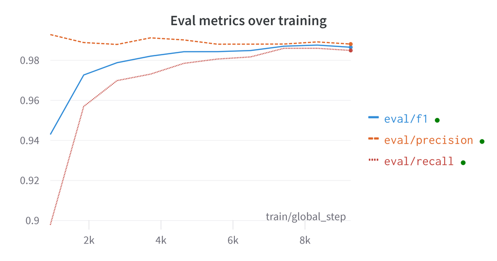

```python
from IPython.display import Image
Image("../images/bert_training_metrics.png")
```

```python
predictions = trainer.predict(encoded_dataset["eval"])
```

```
***** Running Prediction *****
  Num examples = 927
  Batch size = 4
```

[232/232 00:05]

```python
preds = []
for prediction in predictions.predictions:
    preds.append([1 if i>=1 else 0 for i in prediction])
```

### Lets see how well we do on the evaluation set using our neural network

```python
print((classification_report(y_test,preds,target_names=label_names)))
```

```
                     precision    recall  f1-score   support

  atis_abbreviation       1.00      0.89      0.94        27
      atis_aircraft       1.00      1.00      1.00        14
       atis_airfare       0.97      1.00      0.98        91
       atis_airline       0.96      1.00      0.98        23
       atis_airport       0.75      1.00      0.86         3
      atis_capacity       1.00      1.00      1.00         6
          atis_city       1.00      0.50      0.67         4
      atis_distance       1.00      1.00      1.00         4
        atis_flight       1.00      0.99      1.00       692
     atis_flight_no       0.00      0.00      0.00         0
   atis_flight_time       0.75      0.86      0.80         7
   atis_ground_fare       1.00      0.80      0.89         5
atis_ground_service       1.00      1.00      1.00        42
          atis_meal       1.00      0.50      0.67         2
      atis_quantity       1.00      1.00      1.00         9
   atis_restriction       0.00      0.00      0.00         1

          micro avg       0.99      0.99      0.99       930
          macro avg       0.84      0.78      0.80       930
       weighted avg       0.99      0.99      0.99       930
        samples avg       0.98      0.99      0.99       930
```

### Looks good, seems like we are doing quite well, except on the very low sample classes - This model definitely would work for production

### Lets now think about what % of the time we will need human intervention. This should happen in three scenarios

1. Wrong prediction by model
2. No prediction by model (possible in multilabel problem)
3. Not enough samples in class (0.02%, from previous)

#### Calculate wrong prediction by model

```python
from sklearn.metrics import accuracy_score, f1_score
misclassifications = (1-accuracy_score(y_test,preds))* len(predictions.predictions)
print(f"{misclassifications}, or {int(round(misclassifications,0))} samples were misclassified -> {round(misclassifications*100/len(y_test),2)}% ")
```

```
16.999999999999968, or 17 samples were misclassified -> 1.83%
```

#### Calculate no prediction by model

```python
classified, unclassified = 0, 0
for prediction in predictions.predictions:
    if sum([1 if i>=1 else 0 for i in prediction]) == 0 :
        unclassified += 1
    else:
        classified += 1
```

```python
print(f"""Of {len(predictions.predictions)} test samples, {unclassified} were unclassified, or {round(unclassified*100/len(predictions.predictions),2)}%.""")
```

```
Of 927 test samples, 6 were unclassified, or 0.65%.
```

### Get final stats :

```python
print(f"""In total, 0.02% (not enough samples) + 1.83% (wrong prediction) + 0.65% (no prediction) = {1.83+0.02+0.65}%
      This equates to a human intervention rate of 1 human intervention for every ~ {int(round(1/0.025,0))} queries.
      This would reduce manual human intervention time by {100-2.5}%, if implemented.""")
```

```
In total, 0.02% (not enough samples) + 1.83% (wrong prediction) + 0.65% (no prediction) = 2.5%
      This equates to a human intervention rate of 1 human intervention for every ~ 40 queries.
      This would reduce manual human intervention time by 97.5%, if implemented.
```

### Effort saved with model : 97.5% of queries automated | Human Intervention needed : only 1 per 40 queries

### Step 2 : Architecting

- How do we deploy a system that can maintain accuracy over time, is scalable, has visible metrics and logs, and can also be extended further?
- See below for final design and architecture for monitoring and visibility of deployed intents model
- Big idea is we want to save prediction results as well as whatever feedback metrics we can get from user in a database so that we can subsequently use the data to improve the model, as well as visualise those metrics to be sure that our model is still accurate and doing well

### Component choices

- Backend - fastAPI - generally the fastest API backend in python, uses ASGI and also comes with free swagger API documentation
- Metrics storage - prometheus - great time series database for storing real-time metrics
- Metrics visualisation - grafana - great visualisation tool for metrics
- Model Registry - MLFlow - good model registry framework, used to track and register models that would be deployed

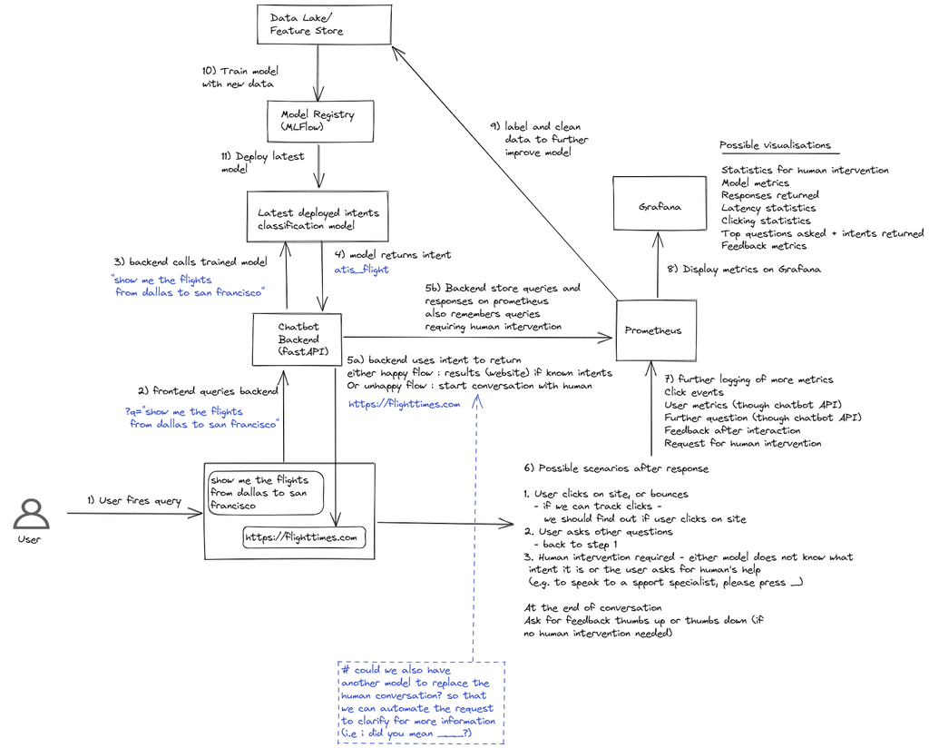

```python
from IPython.display import Image
Image("../images/chatbot_architecture.png")
```